# Applying VAST to an existing theory

Visual Argument Structure Tool (VAST) by Leising, Grenke & Cramer

Felix Schönbrodt

felix.schoenbrodt@psy.lmu.de

Ludwig-Maximilians-Universität München

2026-10-30

## Steps to formalize an existing verbal theory

### Agenda for this presentation

- Step 1: Choose your starting point
- Step 2: Limit your scope
- Step 3: Collect robust empirical phenomena
- Step 4: Collect elements of theory, with reference to the literature –> “Element Table”
- Step 5: Distill a (consensus or working) definition for each construct, draw first VAST display

**Tip**

The full list of formalization steps is presented on this website. This slide set covers steps 1 to 5 of the broader scheme.

## Step 1: Choose your starting point

### Type A: Narrative Theory Reconstruction (NTR)

- *Starting point*: The existing verbal theory.
- *Main tasks*: Read and understand the narrative theory, then formalize it. Check whether a simulation can produce the target phenomenon.
- *Of only minor importance*:
  - Whether the phenomenon is actually robust.
  - Do not fix inconsistencies, do not improve the theory: We want to make explicit what the original authors had in mind with their theory.
- This approach focuses on *showing the gaps* (without fixing them)

## Step 1: Choose your starting point

### Type B: Theory Construction Methodology (TCM)

- *Starting point*: A robust phenomenon.
- *Main tasks*:
  - Understand the phenomenon (its robustness, evidence, moderating conditions, operationalizations; search for meta-analyses).
  - Invent a new theory that can explain the phenomenon, or use an established theory from another domain and make necessary adjustments (could be within psychology, but also from completely different disciplines).
  - Check whether a formal model of your theory produces the phenomenon.
- *Of only minor importance*: Any existing theory that aims to explain the phenomenon. You might compare your own formal model to existing theories later.

## Step 1: Choose your starting point

### A-B Mixture Model (for formalization attempts)

- Starting point is an existing narrative theory
- We soon will detect inconsistencies. For successfully modelling the theory, we have to *resolve* them, e.g. by:
  - Deciding on one specific construct definition
  - Synthesizing multiple definitions
  - Only use robust phenomena as explanatory targets
  - Select only components of the theory that are theoretically central to explain your explanatory target.
- The result will be a *reduced* and *refined* theory, that is inspired by the original theory but not identical to it.
- This approach is more about *filling the gaps* (instead of just showing them).

## Step 2: Limit your scope

Most theories in psychology are too fuzzy and broad to be formalized in one round. We restrict the scope of the theory to keep modelling feasible:

- Define the **scope of original literature** that is used as basis for the formalization.
- Limit the number of **phenomena** that your model is supposed to explain. Focus on phenomena that are empirically robust.
- Limit the number of **constructs** and their **relationships**, add complexity later.
  - Start with the smallest number of constructs necessary to explain your explanatory target.
  - Maybe exclude entire sections of a theory.
  - What is your focal outcome variable (DV)? What are the focal predictors or interventions?

# Step 3: What is the explanatory target? Collect robust empirical phenomena

## Step 3: Collect robust empirical phenomena

Robustness of phenomena has two dimensions:

1. **Generalizability** (cf. UTOS framework): The effect has been shown for different Units, with different operationalizations of Treatments and Outcomes, and in multiple Settings.
2. Strong empirical **evidence** for each/many of the generalizations.

## Step 3: Collect robust empirical phenomena

Practically, you should do the following steps to assess these two dimensions:

1. Search for **meta-analyses** that report on phenomena with our focal variables → Only if no meta-analysis is available, or it is not helpful: Do a broader literature search for primary studies.
2. Assess the robustness of the phenomena along the two dimensions:
   1. How *generalizable* is it? Go through all four UTOS dimensions and evaluate which types of generalization have been shown across studies.
   2. How *strong* is the evidence? (e.g., based on number *k* of studies in a meta-analysis, strength of evidence, risk of bias)
3. Write a paragraph that makes an overall assessment of the robustness of each phenomenon and gives a clear and explicit answer: “The phenomenon can (not) be considered robust because, …”. Refer to the two dimensions of robustness and give references that back up your claim.

## Step 3: Collect robust empirical phenomena

### How to jointly assess “strength of evidence” and “generalizability”

When you assess the generalizability, you should distinguish **three prototypical epistemic states**:

- “I know that it is generalizable.” → strong evidence for $H_1$
- “I know that it is *not* generalizable.” → strong evidence for $H_0$
- “I *do not know* whether it is generalizable or not - with the given empirical evidence I cannot answer this question.” → inconclusive evidence

When is the strength of evidence strong? If …

- you have many studies,
- which are methodologically sound (i.e., valid),
- and show (at least in sum) a decisive statistical result into either direction (i.e., either for a difference, or for a null effect)

As a sidenote: Ideally, evidence is quantified with a statistical technique that also allows to measure evidence *for* the null hypothesis and that gives a continuous quantification of the strength of evidence. A Bayes factor provides both desiderata.

## Step 3: Collect robust empirical phenomena

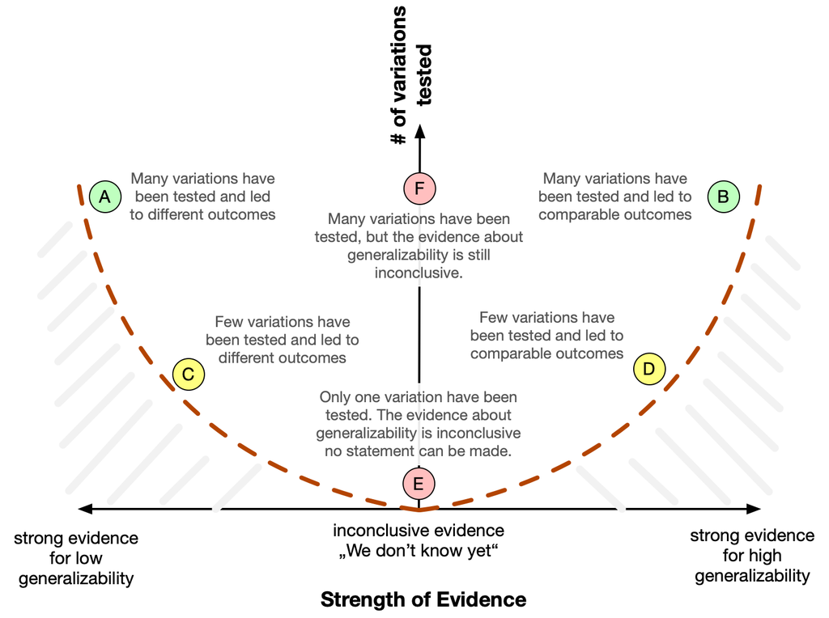

Figure 1: Possible results of a generalizability assessment.

**Note**

General principle: We can only make statements about stuff that we actually studied.

We describe six prototypical examples:

- **(A)**: strong evidence that the phenomenon **is not** generalizable.
- **(B)**: strong evidence that the phenomenon **is** generalizable - at least within the space of sampled variations.
- **(C)**: weak evidence that the phenomenon **is not** generalizable.
- **(D)**: weak evidence that the phenomenon **is** generalizable. As we don’t know about the untested variations, the evidence principally cannot be very strong.
- **(E)**: principally unknowable whether the result generalizes to other variations. We can only conclude that we cannot conclude anything about generalizability.
- **(F)**: evidence is **inconclusive.** There are descriptive differences between variations, but they are small, and it is not clear if these differences are statistically significant and substantial.

## Step 3: Collect robust empirical phenomena

### Exercise (5 min)

All four UTOS dimensions can get an independent assessment. Consider the [ManyLabs2 study](https://journals.sagepub.com/doi/10.1177/2515245918810225), where identical experiment (except translation of materials) has been administered online in very diverse samples (at least diverse with respect to nationality and cultural background).

Non-zero effects could be found with remarkably low variability across samples. Quoted from the abstract:

> “Cumulatively, variability in the observed effect sizes was attributable more to the effect being studied than to the sample or setting in which it was studied”.

**Evaluate the generalizability of the reported effects along the four UTOS dimensions.**

## Step 3: Collect robust empirical phenomena

### Applying the heuristic to ManyLabs2

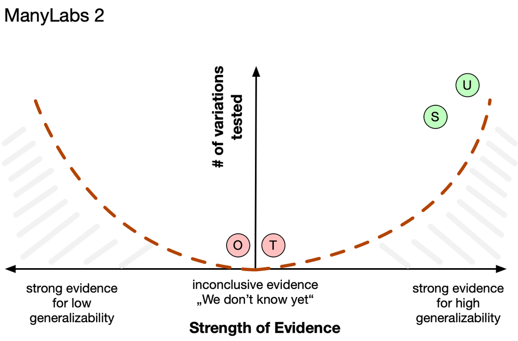

Figure 2: A generalizability assessment of the UTOS dimensions in ManyLabs 2.

Hence, we have strong evidence for high generalizability for the U and the S dimension, but we cannot make a conclusion concerning the T and the O dimensions, as they lacked the necessary variation in the study.

## Step 3: Collect robust empirical phenomena

### Example: Social Loafing (adapted from Emilia Wittig)

“A meta-analysis of 78 studies underlines that social loafing is a robust phenomenon that generalizes across tasks and populations (Karau & Williams, 1993).

Regarding different **units**, social loating was found among groups of organizational employees, college students as well as high school students. Furthermore, the phenomenon appears within different genders as well as various cultures.

The studies mentioned in the meta-analysis used a variety of different tasks as **treatment**, such as physical exercises (e.g., rope pulling), cognitive tasks (e.g., brainstorming), evaluative efforts (e.g., rating items) and perceptual tasks (e.g., monitoring a screen for signals). These tasks also differed in complexity.

Regarding the **outcomes**, social loafing was generally assessed by comparing individual’s coactive efforts with the individual’s collective efforts. The specific units of measurement varied across tasks, with some studies focusing on quantity of individual contributions and others taking the quality into account.

Lastly, concerning different **settings** of studies, the meta analysis included laboratory studies as well as field studies.

In sum, we can conclude that evidence for social loafing found in this meta-analytic review is strong and the phenomenon generalizes over all of the UTOS dimensions. Social Loafing can be consider to be a robust phenomenon.”

## Interlude: Elements of a theory

The *elements* of a theory are:

- *concepts* (i.e., categories or dimensions that are applicable to certain objects)
- *relationships* (typically causal) among these concepts

Musfeld et al. ([2026](https://osf.io/preprints/psyarxiv/e7tdc_v4))

## Step 4: Collect definitions of constructs

### Element Table (Constructs + Relationships)

- Collect quotes of definitions of constructs and their relationships from the literature.
  - If there is no quote for a construct that is still needed: Create a provisional definition based on your understanding, without any quote, and mark it as such.
- Make them atomic (i.e., split up long quotes into their basic components - see column “Extracted Element”).
- Assign a unique ID to each statement.

| Reference | Quote | Extracted element | Element type | Rel. type | Short name / associated concept | ID |
| --- | --- | --- | --- | --- | --- | --- |
| Fischer et al. (2011), p. 517 | “The bystander effect refers to the phenomenon that an individual’s likelihood of helping decreases when passive bystanders are present in a critical situation.” | likelihood of helping | C | n | p(help) | A1 |
|  |  | number of passive bystanders | C | n | NOPB | A2 |
|  |  | critical situation | C | n | critSit | A3 |
|  |  | p(help) *decreases* when NOPB > 0, given critSit | R | p | A1 ~ A2 + A3 | A4 |

- *Element Type* is one of: Concept, Relationship, Data (anything related to empirical evidence), HOC: Higher-Order Concept.
- *Relationship Type*: One of the VAST relationship types (n, p, i, r, c, …)

## Step 4: Collect definitions of constructs

### Element Table (Constructs + Relationships)

- Relationships typically have no short names / labels. Instead spell out the relationship with the involved concepts, using `~` as the symbol for “is a function of” (e.g., `Y ~ X+M` means “Y is a function of X and M”)
- A phenomenon is (minimally) the triplet of “(i) Concept X exists, (ii) concept Y exists, (iii) X predicts Y”, which is a higher order concept (HOC) in the VAST terminology.

## Step 5: Distill a working definition for each construct, draw first VAST display

- Draw a VAST display with a naming (`n`) relationship for each construct.
- Use the ID from the *Element Table* as subscript for each relationship. This way your claims in the VAST display can be easily backlinked to the original sources in the literature.
  - The small $A$, $A_1$ etc. subscripts indicates that the relationships in this display are derived from the quote with IDs $A$, $A_1$, etc. in the *Element Table*.

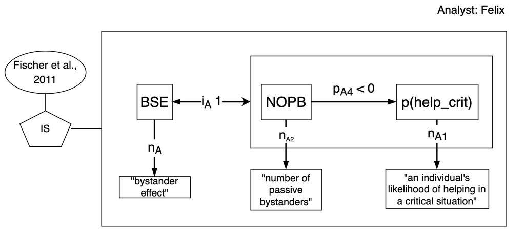

# A useful standard setup for psychological theories

## Sensors

### Perceiving the environment

Organisms have a vast range of sensors for perceiving their environment. These have been adapted to selection pressures:

- Humans don’t have sensors for ultraviolet light (bees do)
- We have no sensors for radioactivity, as this was no relevant selection pressure
- Single-celled organism have, for example …
  - chemoreceptors for sugar
  - tactile sense (simple membranes transmitting changes in pressure)

## Sensors

### Brunswik’s lens model

- Organisms constantly need to form a judgement about latent properties of situations and objects (the criterion)
- Most criteria are not directly observable, but need to be inferred via cues. Example:
  - Latent property: The caloric energy of a dessert
  - Cues: Size, taste, color
- Cues often are not perfect indicators, but rather statistically correlated with the criterion.  
  Higher correlation → higher cue validity
- Not all cues are used (with the same weight) in judgement formation → cue utilization

Brunswik, E. (1952). The conceptual framework of psychology. (Int. Encycl. unified Sci., v. 1, no. 10.). Oxford, England: Univ. Chicago Press.

## Sensors

### Brunswik’s lens model

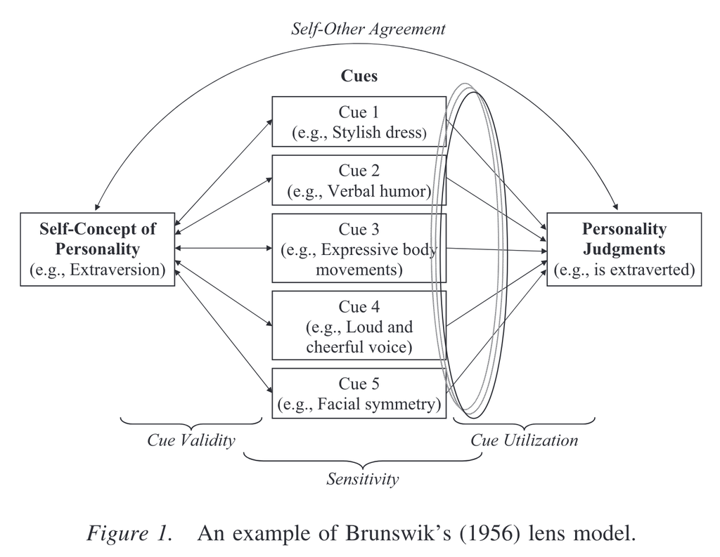

Fig. 1 from Hirschmüller et al. (2013). https://doi.org/10.1037/a0030383

## Sensors

### Implementing the lens model in a VAST display

Principle:

- Draw a box (“higher-order concept”) that represents an organism with its boundaries
- Any external information must enter the organism via a *sensor*
- Arrows going into a sensor must come from observable cues
- Arrows going out of sensors are the organism’s representation of the phenomenon in the environment
- The lens model (i.e., the weights of cue usage & utilization) is implemented in the sensor box
- No arrow may directly cross the organisms border$*$

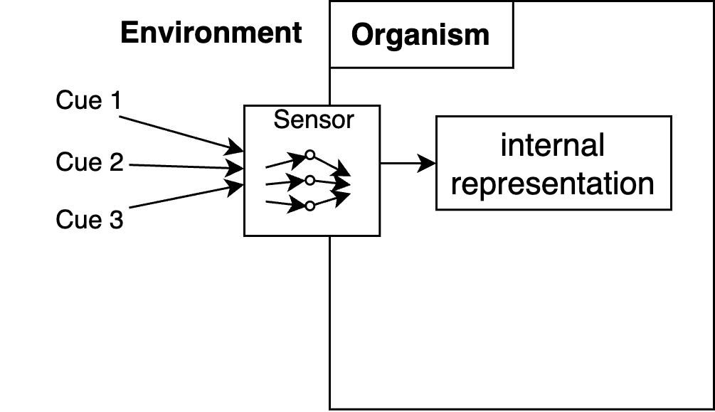

$*$ If we do so, then it is a shortcut, assuming that the external observable cue is perfectly represented inside the organism

## Actors

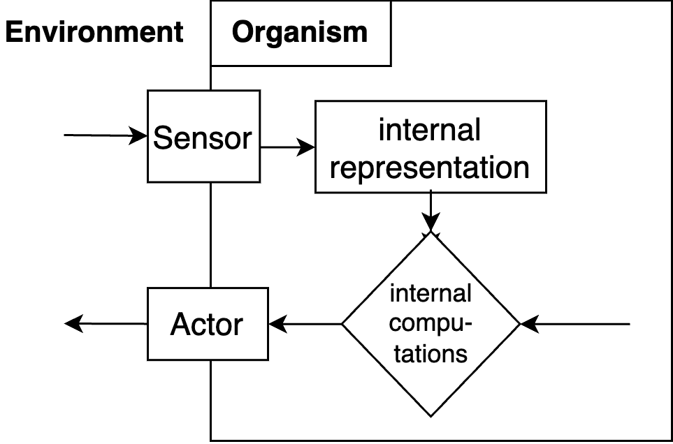

Sensing the environment only makes sense when organisms are able to react on this information. Devices that allow to manipulate the environment (or the organism’s position within the environment) are called actors.

# End

## Contact

- [@nicebread@scicomm.xyz](https://scicomm.xyz/@nicebread)
- ed.uml.ysp@tdorbneohcs.xilef
- https://www.nicebread.de
- https://github.com/nicebread

CC-BY-SA 4.0